# **Food Accessibility and Food Deserts in Chicago**

## Rhegan Barrett & Kayla Willis

https://Kayla200212.github.io/

# Project Overview

This project uses multiple grocery store datasets as well as census data for the city of Chicago to analyze food accessibility and inequality by zipcode. Some of the questions we hoped to answer were:

- Is there a direct correlation between impoverished areas and a lower number of grocery stores, and vice versa?
- Do an increased number of dollar stores indicate impoverished areas?
- Do an increased number of luxury grocery stores indicate affluent areas?

# Public datasets

https://catalog.data.gov/dataset/grocery-stores-2013/resource/4d1c5d3e-71f9-4a81-94ca-0bec6afa2b62

https://data.cityofchicago.org/Health-Human-Services/Per-Capita-Income/r6ad-wvtk

# Collaboration Plan

We plan to meet once weekly in person or over Zoom, if necessary. We have this colab as well as a GitHub set up to collaborate on the project.

```python
#begin by implementing the necessary packages and reimorting the github files
import pandas as pd
import numpy as np
import matplotlib.pyplot as plt
import requests
from bs4 import BeautifulSoup
import shapefile
import geopandas as gpd
%cd /content
!rm -r Kayla200212.github.io
!git clone https://github.com/kayla200212/Kayla200212.github.io
%cd /content/Kayla200212.github.io/Datasets
```

```
/content
Cloning into 'Kayla200212.github.io'...
remote: Enumerating objects: 122, done.
remote: Counting objects: 100% (122/122), done.
remote: Compressing objects: 100% (113/113), done.
remote: Total 122 (delta 31), reused 0 (delta 0), pack-reused 0 (from 0)
Receiving objects: 100% (122/122), 1.00 MiB | 7.91 MiB/s, done.
Resolving deltas: 100% (31/31), done.
/content/Kayla200212.github.io/Datasets
```

# First Dataset: Grocery Stores in Chicago 2013

Our first data set is one that provides a list of all grocery stores in Chicago from 2013. This dataset comes from the City of Chicago’s business license data. Unfortunately, this dataset is slightly outdated (ex: one grocery store that appears in the dataset is Dominick’s, a store that went out of business), but it was the only publically available dataset with a comprehensive list of stores. We also noticed that some of the “grocery stores” included in the list are convenience stores such as Walgreens. While Walgreens does technically have groceries, it’s not a fully stocked grocery store so we decided to filter it out of the dataset. Likewise, there were a number of liquor stores that technically contain food, but would not be considered a store with considerable food options. Though there are likely stores that do not get removed based on these two filters that should be, with the size of the dataset, this was the most reasonable option. Choices such as these can help further guide our ETL steps as we gather and combine more datasets. The two most important variables in this data set are the name of the grocery store and the neighborhood the grocery store is in. One question we can ask using these metrics: which neighborhoods have the least amount of grocery stores? By using this as a starting point, we can use this to begin analysis of food inequality through comparison with other datasets.

```python
#read in our two datasets
chicago_2013 = pd.read_csv("../Datasets/Grocery_in_Chicago_2013.csv")
chic_per_cap = pd.read_csv("../Datasets/Chicago_Per_capita.csv")
#remove a handfull of columns which we do not need for this analysis for tidy purposes
chicago_2013 = chicago_2013.drop(chicago_2013.columns[[1, 3, 12, 13, 14, 15]], axis=1)
#set the index to the name, ok bc duplicates have an ID number
chicago_2013.set_index("STORE NAME")
#remove (for now) non "grocery stores" like walgreens
chicago_2013 = chicago_2013[~chicago_2013['STORE NAME'].str.contains('WALGREENS')]
chicago_2013 = chicago_2013[~chicago_2013['STORE NAME'].str.contains('LIQUOR')]
chicago_2013
```

|  | STORE NAME | ACCOUNT NUMBER | BUFFER SIZE | ADDRESS | ZIP CODE | COMMUNITY AREA NAME | COMMUNITY AREA | WARD | CENSUS TRACT | CENSUS BLOCK | LOCATION |
| --- | --- | --- | --- | --- | --- | --- | --- | --- | --- | --- | --- |
| 1 | QUICK STOP FOOD MART | 3604.0 | B | 2751 W PRATT BLVD | 60645 | WEST RIDGE | 2 | 50 | 17031020601 | 1.703102e+14 | (42.0047500731, -87.6994227766) |
| 2 | DOMINICK'S #147/1147 | 5033.0 | A | 1340 S CANAL ST | 60607 | NEAR WEST SIDE | 28 | 2 | 17031841900 | 1.703184e+14 | (41.8645211937, -87.6393040996) |
| 3 | CERMAK PRODUCE | 279468.0 | A | 5220 S PULASKI RD | 60632 | WEST ELSDON | 62 | 23 | 17031620200 | 1.703162e+14 | (41.79799187, -87.7234437408) |
| 4 | WHOLE FOODS MARKET | 86298.0 | B | 3300 N ASHLAND AVE | 60657 | LAKE VIEW | 6 | 44 | 17031062500 | 1.703106e+14 | (41.9415658578, -87.6688604029) |
| 5 | PATEL BROS | 88729.0 | B | 2610 W DEVON AVE | 60659 | WEST RIDGE | 2 | 50 | 17031020602 | 1.703102e+14 | (41.9977473006, -87.6952511581) |
| ... | ... | ... | ... | ... | ... | ... | ... | ... | ... | ... | ... |
| 500 | JEWEL FOOD STORE #3114 | 259.0 | A | 3128 W 103RD ST | 60655 | MOUNT GREENWOOD | 74 | 19 | 17031740100 | 1.703174e+14 | (41.7063128446, -87.6997671192) |
| 502 | TIERRA CALIENTE MARKET | 311388.0 | B | 1402 N ASHLAND AVE | 60622 | WEST TOWN | 24 | 1 | 17031241500 | 1.703124e+14 | (41.9071018181, -87.6677396553) |
| 503 | QUALITY FOOD ON 71 ST INC | 22614.0 | B | 2557 W 71ST ST | 60629 | CHICAGO LAWN | 66 | 18 | 17031661000 | 1.703166e+14 | (41.7645116769, -87.687986655) |
| 504 | JEWEL FOOD STORE #3302 | 259.0 | A | 3644 S ARCHER AVE | 60609 | MCKINLEY PARK | 59 | 11 | 17031590500 | 1.703159e+14 | (41.8275838968, -87.6824544425) |
| 505 | CERMAK PRODUCE | 311980.0 | A | 3311 W 26TH ST | 60623 | SOUTH LAWNDALE | 30 | 22 | 17031840800 | 1.703184e+14 | (41.8443667287, -87.7078980538) |

443 rows × 11 columns

```python
#count how many times each community area name is in the dataset indicating a store
count = chicago_2013['COMMUNITY AREA NAME'].value_counts()
count
```

| COMMUNITY AREA NAME | count |
| --- | --- |
| BELMONT CRAGIN | 21 |
| SOUTH LAWNDALE | 21 |
| WEST RIDGE | 18 |
| NEAR NORTH SIDE | 17 |
| UPTOWN | 15 |
| ... | ... |
| WASHINGTON PARK | 1 |
| DOUGLAS | 1 |
| BEVERLY | 1 |
| MONTCLARE | 1 |
| BRIDGEPORT | 1 |

73 rows × 1 columns

**dtype:** int64

# First Dataset Findings

This data exploration of the grocery store dataset from 2013 is not the most useful to non-Chicago natives, as it is divided by community area names. However, this analysis does show that there is a range in store count, with multiple areas having 13+ stores and multiple having only 1. This was promising, but prompted a second dataset which would reveal the census statistics for each of these areas.

# Second Dataset and Merging

This leads us into our next dataset, which provides the per-capita income of each neighborhood in Chicago.

This dataset uses six socioeconomic indicators such as per-capita income and percent of households in the neighborhood below poverty. This data comes from the Census and uses the same “Community Area Name” variable as the grocery store dataset, which will allow us to easily merge the datasets. We can use both of these datasets in conjunction to answer another question: what is the link between grocery store accessibility and socioeconomic markers of inequality?

```python
#make the community area name column all caps so it is identical to the one in counts
chic_per_cap["COMMUNITY AREA NAME"] = chic_per_cap["COMMUNITY AREA NAME"].str.upper()
#change counted into a dataframe for manipulation purposes
counted = count.to_frame()

#change the index into a default so we can manipulate community area name
counted.reset_index(drop=False, inplace=True)

#merge per capita df and the count so we can compare census data with # stores
merged = chic_per_cap.merge(counted, on="COMMUNITY AREA NAME", how="inner")
merged = merged.sort_values(by=["count"], ascending=True)#sort by # of stores
merged #display the top and bottom 5 store count areas with census data
```

|  | Community Area Number | COMMUNITY AREA NAME | PERCENT OF HOUSING CROWDED | PERCENT HOUSEHOLDS BELOW POVERTY | PERCENT AGED 16+ UNEMPLOYED | PERCENT AGED 25+ WITHOUT HIGH SCHOOL DIPLOMA | PERCENT AGED UNDER 18 OR OVER 64 | PER CAPITA INCOME | HARDSHIP INDEX | count |
| --- | --- | --- | --- | --- | --- | --- | --- | --- | --- | --- |
| 33 | 35.0 | DOUGLAS | 1.8 | 29.6 | 18.2 | 14.3 | 30.7 | 23791 | 47.0 | 1 |
| 66 | 72.0 | BEVERLY | 0.9 | 5.1 | 8.0 | 3.7 | 40.5 | 39523 | 12.0 | 1 |
| 49 | 54.0 | RIVERDALE | 5.8 | 56.5 | 34.6 | 27.5 | 51.5 | 8201 | 98.0 | 1 |
| 55 | 60.0 | BRIDGEPORT | 4.5 | 18.9 | 13.7 | 22.2 | 31.3 | 22694 | 43.0 | 1 |
| 36 | 40.0 | WASHINGTON PARK | 5.6 | 42.1 | 28.6 | 25.4 | 42.8 | 13785 | 88.0 | 1 |
| ... | ... | ... | ... | ... | ... | ... | ... | ... | ... | ... |
| 2 | 3.0 | UPTOWN | 3.8 | 24.0 | 8.9 | 11.8 | 22.2 | 35787 | 20.0 | 15 |
| 7 | 8.0 | NEAR NORTH SIDE | 1.9 | 12.9 | 7.0 | 2.5 | 22.6 | 88669 | 1.0 | 17 |
| 1 | 2.0 | WEST RIDGE | 7.8 | 17.2 | 8.8 | 20.8 | 38.5 | 23040 | 46.0 | 18 |
| 17 | 19.0 | BELMONT CRAGIN | 10.8 | 18.7 | 14.6 | 37.3 | 37.3 | 15461 | 70.0 | 21 |
| 28 | 30.0 | SOUTH LAWNDALE | 15.2 | 30.7 | 15.8 | 54.8 | 33.8 | 10402 | 96.0 | 21 |

70 rows × 10 columns

# Scatterplots

Below are two visualizations of the combined datasets. The combined set allows us to look at multiple variable combinations, below are two that made the most sense for our initial investigation.

```
Slope:  250.44391343552687
R^2:  0.005756927942071832
```

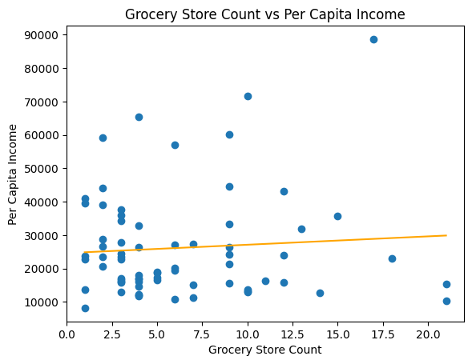

```python
#create x and y
x = merged["count"]
y = merged.iloc[:, 7]
plt.scatter(x, y)
#create a line based on x and y, fed into m(slope) and b(yint)
m, b = np.polyfit(x, y, 1)
plt.plot(x, m*x + b, color='orange')#this is the slope formula y=mx+b to make the line
print("Slope: ", m)
y_pred = m * x + b #consolidate the linear regression equation to do stats

#r squared equation
ss_total = np.sum((y - np.mean(y))**2)  #total sum of squares
ss_residual = np.sum((y - y_pred)**2)  #residual sum of squares
r_squared = 1 - (ss_residual / ss_total)
print("R^2: ", r_squared)
#add some labels
plt.xlabel("Grocery Store Count")
plt.ylabel("Per Capita Income")
plt.title("Grocery Store Count vs Per Capita Income")
plt.show()
```

```
Slope:  0.37339945897204735
R^2:  0.0038416450733392837
```

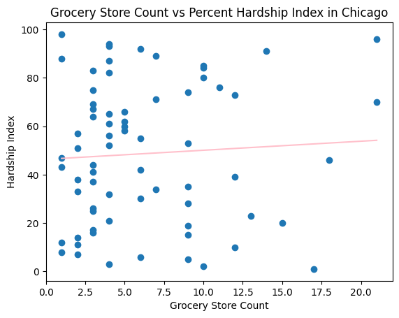

```python
#same as above, for a different y value
x = merged["count"]
y = merged["HARDSHIP INDEX"]
plt.scatter(x, y)

m, b = np.polyfit(x, y, 1)  # m is the slope, b is the intercept
plt.plot(x, m*x + b, color='pink')#this is the slope formula y=mx+b to make the line
print("Slope: ", m)
y_pred = m * x + b #consolidate the linear regression equation to do stats

#r squared equation
ss_total = np.sum((y - np.mean(y))**2)  #total sum of squares
ss_residual = np.sum((y - y_pred)**2)  #residual sum of squares
r_squared = 1 - (ss_residual / ss_total)
print("R^2: ", r_squared)
plt.xlabel("Grocery Store Count")
plt.ylabel("Hardship Index")
plt.title("Grocery Store Count vs Percent Hardship Index in Chicago")
plt.show()
```

# Initial Findings

From our initial visualizations, the connection is vague. We visualized how the number of grocery stores per community area related to the hardship index and per capita income, respectively, and both had slight positive correlations which would indicate that an increase in stores meant both higher hardship index and higher income, but barely.

At this stage, we were encouraged to find a more recent dataset with stores we were familiar with, that we could know for certain were grocery stores or dollar stores. At present, most of the communities have less than 6 stores in them, with a few skewing towards having more than 15. More data on grocery stores in these areas would create more validity to our findings. Secondly, if we are able to classify the price range of each grocery store, this would also help us understand these results on a deeper level. Even if an area has a large amount of stores, they could be dollar stores or stores comparable to Walgreens. Knowing the price range of the stores included in the survey would also allow us to better understand the data and results.

# Third Dataset

We wanted to do a comparison of "luxury" grocery stores to dollar stores, as an increase in dollar stores are often an indicator of food insecure neighborhoods (https://anderson-review.ucla.edu/how-dollar-stores-contribute-to-food-deserts/). However, there were no free datasets of these stores in Chicago. So, we used webscraping to find locations by zipcode of Whole Foods, Marianos (luxury), Dollar Trees, and Family Dollars.

```python
urlDT = "https://www.dollartree.com/locations/il/chicago/"
headers = {'user-agent': 'Mozilla/5.0 (Macintosh; Intel Mac OS X 10_15_7) AppleWebKit/537.36 (KHTML, like Gecko) Chrome/104.0.5112.79 Safari/537.36'}

r = requests.get(urlDT, headers=headers)#get the webpage
#print(r.status_code)#print the status code (200 this time so success)

soupy = BeautifulSoup(r.content)#use beautifulsoup to read the page
#find all the strings containing 606 (aka the area code)
results = soupy.find_all(string=lambda text: "606" in text)
dollartreeDF = pd.DataFrame(columns=["Zipcode"])
for result in results:
  #print(result)#print out every chicago areacode
  row = {"Zipcode":result}
  dollartreeDF = pd.concat([dollartreeDF,pd.DataFrame([row])],ignore_index=True)
dollartreeDF.head()
```

|  | Zipcode |
| --- | --- |
| 0 | 60655 |
| 1 | 60628 |
| 2 | 60655 |
| 3 | 60643 |
| 4 | 60620 |

- Luckily dollartree lets us webscrape. Using techniques from lab 11, we were able to look for all of the zipcodes where there was a dollartree in Chicago
- We searched for strings containing 606 (the first part of a Chicago zipcode), and luckily again, on the webpage only the store zipcodes contained that string and were returned. Later, we can look at the frequency to see how many dollartrees there were in each zipcode. But for now we will do this same process for a few other chains.

```python
urlFD = "https://www.familydollar.com/locations/il/chicago/"
headers = {'user-agent': 'Mozilla/5.0 (Macintosh; Intel Mac OS X 10_15_7) AppleWebKit/537.36 (KHTML, like Gecko) Chrome/104.0.5112.79 Safari/537.36'}

r = requests.get(urlFD, headers=headers)#get the webpage
print(r.status_code)#print the status code (200 this time so success)
soupy = BeautifulSoup(r.content)#use beautifulsoup to read the page
#find all the strings containing 606 (aka the area code)
results = soupy.find_all(string=lambda text: "606" in text)
familyDF = pd.DataFrame(columns=["Zipcode"])
for result in results:
  #print(result)#print out every chicago areacode
  if len(result) == 5:#it was returning non zipcodes, so filtering on length fixes this
    row = {"Zipcode":result}
    familyDF = pd.concat([familyDF,pd.DataFrame([row])],ignore_index=True)
familyDF
```

```
200
```

|  | Zipcode |
| --- | --- |
| 0 | 60628 |
| 1 | 60629 |
| 2 | 60634 |
| 3 | 60643 |
| 4 | 60623 |
| ... | ... |
| 60 | 60632 |
| 61 | 60619 |
| 62 | 60617 |
| 63 | 60634 |
| 64 | 60638 |

65 rows × 1 columns

Family Dollar was slightly trickier, making us do an additional filter on string length as it was returning non zipcodes. But, by ensuring the string was 5 characters we were able to filter out everything but the zipcodes. This will complete our set of dollar stores.

```python
#https://www.wholefoodsmarket.com/stores
wholefoods = {'Zipcode':['60654','60611','60661','60661','60642','60607','60657',
                         '60613','60660','60615','60646']}
wholefoodsDF = pd.DataFrame(wholefoods)
wholefoodsDF
```

|  | Zipcode |
| --- | --- |
| 0 | 60654 |
| 1 | 60611 |
| 2 | 60661 |
| 3 | 60661 |
| 4 | 60642 |
| 5 | 60607 |
| 6 | 60657 |
| 7 | 60613 |
| 8 | 60660 |
| 9 | 60615 |
| 10 | 60646 |

```python
#https://www.marianos.com/stores/grocery/il/chicago
marianos = {'Zipcode':['60657','60608','60653','60614','60640','60630','60601',
                       '60610','60640','60618','60616','60622','60661']}
mariDF = pd.DataFrame(marianos)
mariDF
```

|  | Zipcode |
| --- | --- |
| 0 | 60657 |
| 1 | 60608 |
| 2 | 60653 |
| 3 | 60614 |
| 4 | 60640 |
| 5 | 60630 |
| 6 | 60601 |
| 7 | 60610 |
| 8 | 60640 |
| 9 | 60618 |
| 10 | 60616 |
| 11 | 60622 |
| 12 | 60661 |

Now, we will do a value_counts to check for frequency of each unique zipcode which will give us the density of stores in each zipcode. We also needed to make sure this was saved as a dataframe (for ease of display later), naming the count variable "Count" and giving it a default index.

```python
countDT = dollartreeDF["Zipcode"].value_counts().to_frame('Count').reset_index()
countWF = wholefoodsDF["Zipcode"].value_counts().to_frame('Count').reset_index()
countFD = familyDF["Zipcode"].value_counts().to_frame('Count').reset_index()
countMari = mariDF["Zipcode"].value_counts().to_frame('Count').reset_index()
```

# Visualizing Store Concentrations

Since we have two dollar store chains and two luxury store chains, we will eventually combine these for a more simple visualization and do some overall comparisons a bit later. For now, we'll look at the family dollar and dollar tree datasets compared to eachother, more or less as a sanity check to see if they show similar zipcode concentrations.

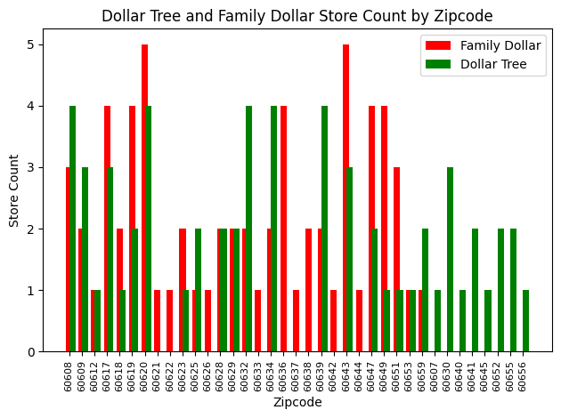

```python
countFD.sort_values("Zipcode", inplace=True)#sort it by zipcode
countDT.sort_values("Zipcode", inplace=True)
bar_width = 0.5#make the bars relatively small so we can fit everything
fig, ax = plt.subplots()#we're gonna be plotting two DFs on one plot
#read in both DFs, shifting the second one slightly so we can see everything without taking too much space
bars1 = ax.bar(countFD['Zipcode'], countFD['Count'], bar_width, color="red", label='Family Dollar')
bars2 = ax.bar(countDT['Zipcode'], countDT['Count'], bar_width, color="green",label='Dollar Tree', align='edge')

ax.set_xlabel('Zipcode')#labels
ax.set_ylabel('Store Count')
ax.set_title('Dollar Tree and Family Dollar Store Count by Zipcode')#title
ax.legend()#legend
plt.xticks(rotation=90, fontsize=8)#make it legible
plt.tight_layout()#this makes them overlap less
plt.show()
```

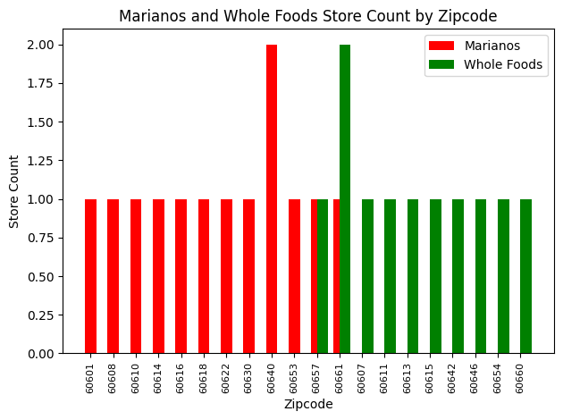

```python
countMari.sort_values("Zipcode", inplace=True)#sort it by zipcode
countWF.sort_values("Zipcode", inplace=True)
bar_width = 0.5#make the bars relatively small so we can fit everything
fig, ax = plt.subplots()#we're gonna be plotting two DFs on one plot
#read in both DFs, shifting the second one slightly so we can see everything without taking too much space
bars1 = ax.bar(countMari['Zipcode'], countMari['Count'], bar_width, color="red", label='Marianos')
bars2 = ax.bar(countWF['Zipcode'], countWF['Count'], bar_width, color="green",label='Whole Foods', align='edge')

ax.set_xlabel('Zipcode')#labels
ax.set_ylabel('Store Count')
ax.set_title('Marianos and Whole Foods Store Count by Zipcode')#title
ax.legend()#legend
plt.xticks(rotation=90, fontsize=8)#make it ledgible
plt.tight_layout()#this makes them overlap less
plt.show()
```

Now, we can combine the dollar stores and the luxury stores (mainly because there are significantly fewer luxury stores) and do a similar visualization.

```python
dollars_merged = pd.concat([countDT, countFD])#merge the two datasets
#now group them by zipcode and combine the count for identical zipcodes
df_combo_dollar = dollars_merged.groupby('Zipcode').agg({'Count': 'sum'}).reset_index()
df_combo_dollar.sort_values("Zipcode",inplace=True)#make zipcode the count
```

```python
luxury_merged = pd.concat([countWF, countMari])#same as above, with luxury stores
df_combined_lux = luxury_merged.groupby('Zipcode').agg({'Count': 'sum'}).reset_index()
df_combined_lux.sort_values("Zipcode", inplace=True)
```

Now that we have two datasets, one with dollar stores and one with luxury stores, we can do some visualizations.

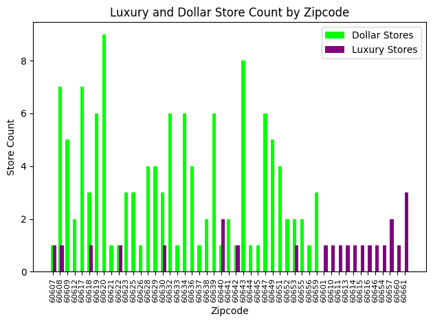

```python
bar_width = 0.5#make the bars relatively small so we can fit everything
fig, ax = plt.subplots()#we're gonna be plotting two DFs on one plot
#read in both DFs, shifting the second one slightly so we can see everything without taking too much space
bars1 = ax.bar(df_combo_dollar['Zipcode'], df_combo_dollar['Count'], bar_width, color="lime", label='Dollar Stores')
bars2 = ax.bar(df_combined_lux['Zipcode'], df_combined_lux['Count'], bar_width, color="purple",label='Luxury Stores', align='edge')

ax.set_xlabel('Zipcode')#labels
ax.set_ylabel('Store Count')
ax.set_title('Luxury and Dollar Store Count by Zipcode')#title
ax.legend()#legend
plt.xticks(rotation=90, fontsize=8)#make it ledgible
plt.tight_layout()#this makes them overlap less
plt.show()
```

Now, we'll read in a CSV that corresponds each community area with the zipcodes within it. For each community area, there are 1-4 zipcodes within it. While this is not as precise as we would like, this step is necessary as the store location data is stored by zipcode. At the same time, we will do some trimming to eliminate the unnecessary columns.

```python
#read in the csv that has the zipcodes and community areas
area_to_zip = pd.read_csv("/content/Kayla200212.github.io/Datasets/Community_Area_Zipcodes.csv")
df_combo_dollar['Zipcode'] = df_combo_dollar['Zipcode'].astype(int)

chic_per_cap.rename(columns={'Community Area Number': 'CHGOCA'}, inplace=True)

#load in the area to zipcode as the left table
#join with the chic per capita table, comm row to each instance
zips_per_cap = pd.merge(area_to_zip,chic_per_cap, on="CHGOCA")
zips_per_cap.rename(columns={'CHGOCA': 'CommAreaCode', 'ZCTA5':'Zipcode'}, inplace=True)
zips_per_cap.drop(columns=["TOT2010","CommAreaCode","COMMUNITY AREA NAME"], inplace=True)
zips_per_cap
```

|  | Zipcode | PERCENT OF HOUSING CROWDED | PERCENT HOUSEHOLDS BELOW POVERTY | PERCENT AGED 16+ UNEMPLOYED | PERCENT AGED 25+ WITHOUT HIGH SCHOOL DIPLOMA | PERCENT AGED UNDER 18 OR OVER 64 | PER CAPITA INCOME | HARDSHIP INDEX |
| --- | --- | --- | --- | --- | --- | --- | --- | --- |
| 0 | 60626 | 7.7 | 23.6 | 8.7 | 18.2 | 27.5 | 23939 | 39.0 |
| 1 | 60645 | 7.7 | 23.6 | 8.7 | 18.2 | 27.5 | 23939 | 39.0 |
| 2 | 60660 | 7.7 | 23.6 | 8.7 | 18.2 | 27.5 | 23939 | 39.0 |
| 3 | 60626 | 7.8 | 17.2 | 8.8 | 20.8 | 38.5 | 23040 | 46.0 |
| 4 | 60645 | 7.8 | 17.2 | 8.8 | 20.8 | 38.5 | 23040 | 46.0 |
| ... | ... | ... | ... | ... | ... | ... | ... | ... |
| 229 | 60634 | 3.6 | 15.4 | 7.1 | 10.9 | 30.3 | 25828 | 24.0 |
| 230 | 60656 | 3.6 | 15.4 | 7.1 | 10.9 | 30.3 | 25828 | 24.0 |
| 231 | 60706 | 3.6 | 15.4 | 7.1 | 10.9 | 30.3 | 25828 | 24.0 |
| 232 | 60640 | 4.1 | 18.2 | 9.2 | 9.7 | 23.8 | 33385 | 19.0 |
| 233 | 60660 | 4.1 | 18.2 | 9.2 | 9.7 | 23.8 | 33385 | 19.0 |

234 rows × 8 columns

Let's rename the "Count" column on the luxury and dollar store sets so that we can look at all of the datasets together. Then, we can merge all three dataframes together and do some sorting to look through the data for any trends we might see on first glance.

```python
df_combined_lux['Zipcode'] = df_combined_lux['Zipcode'].astype(int)
df_combined_lux = df_combined_lux.rename(columns={'Count': 'Luxury Store Count'})
df_combo_dollar = df_combo_dollar.rename(columns={'Count': 'Dollar Store Count'})

lux_per_cap = pd.merge(zips_per_cap,df_combined_lux,on="Zipcode", how="outer")
stores_per_cap = pd.merge(lux_per_cap,df_combo_dollar,on="Zipcode", how="outer")
stores_per_cap = stores_per_cap.fillna(0) #replace the NaN's with 0, the NaN are
#the gaps where there were a luxury store but no dollar & vice versa
stores_per_cap.sort_values(by="Dollar Store Count")
```

|  | Zipcode | PERCENT OF HOUSING CROWDED | PERCENT HOUSEHOLDS BELOW POVERTY | PERCENT AGED 16+ UNEMPLOYED | PERCENT AGED 25+ WITHOUT HIGH SCHOOL DIPLOMA | PERCENT AGED UNDER 18 OR OVER 64 | PER CAPITA INCOME | HARDSHIP INDEX | Luxury Store Count | Dollar Store Count |
| --- | --- | --- | --- | --- | --- | --- | --- | --- | --- | --- |
| 0 | 60007 | 3.6 | 15.4 | 7.1 | 10.9 | 30.3 | 25828 | 24.0 | 0.0 | 0.0 |
| 180 | 60646 | 2.7 | 8.6 | 12.4 | 13.4 | 35.5 | 27751 | 25.0 | 1.0 | 0.0 |
| 179 | 60646 | 2.0 | 5.4 | 9.0 | 11.5 | 39.5 | 32875 | 21.0 | 1.0 | 0.0 |
| 126 | 60631 | 3.6 | 15.4 | 7.1 | 10.9 | 30.3 | 25828 | 24.0 | 0.0 | 0.0 |
| 125 | 60631 | 2.0 | 5.4 | 9.0 | 11.5 | 39.5 | 32875 | 21.0 | 0.0 | 0.0 |
| ... | ... | ... | ... | ... | ... | ... | ... | ... | ... | ... |
| 82 | 60620 | 4.0 | 10.4 | 11.7 | 17.7 | 36.9 | 23482 | 37.0 | 0.0 | 9.0 |
| 81 | 60620 | 3.6 | 29.6 | 23.0 | 16.5 | 41.0 | 17285 | 66.0 | 0.0 | 9.0 |
| 80 | 60620 | 3.8 | 46.6 | 28.0 | 28.5 | 42.5 | 11888 | 94.0 | 0.0 | 9.0 |
| 85 | 60620 | 1.1 | 16.9 | 20.8 | 13.7 | 42.6 | 19713 | 48.0 | 0.0 | 9.0 |
| 84 | 60620 | 0.9 | 5.1 | 8.0 | 3.7 | 40.5 | 39523 | 12.0 | 0.0 | 9.0 |

234 rows × 10 columns

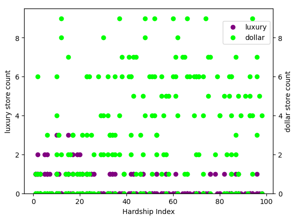

```python
fig, ax1 = plt.subplots()

#plot the first y-value
scatter1 = ax1.scatter(stores_per_cap.iloc[:, 7], stores_per_cap['Luxury Store Count'], color='purple', label='luxury')
#plt.legend(loc='center right')
#create a second y-axis
ax2 = ax1.twinx()

#plot the second y-value
scatter2 = ax2.scatter(stores_per_cap.iloc[:, 7], stores_per_cap['Dollar Store Count'], color='lime', label='dollar')

#set labels and legends
ax1.set_xlabel('Hardship Index')
ax1.set_ylabel('luxury store count')
ax2.set_ylabel('dollar store count')
ax1.set_ylim(0, 9.5)
ax2.set_ylim(0,9.5)
fig.legend(handles=[scatter1, scatter2], loc=[.75,.8])

plt.show()
```

This graph is very busy, but interestingly, the locations where there were 2 or 3 luxury stores (of which there were very few), are all located below the 20% hardship index. Other than this, the graph is a little hard to decipher.

```python
#for each store count (ex, 0-9) average hardship index
avg_hardship_dollar = stores_per_cap.groupby('Dollar Store Count')['HARDSHIP INDEX'].mean().reset_index()
avg_hardship_dollar
```

|  | Dollar Store Count | HARDSHIP INDEX |
| --- | --- | --- |
| 0 | 0.0 | 28.323944 |
| 1 | 1.0 | 40.166667 |
| 2 | 2.0 | 45.681818 |
| 3 | 3.0 | 35.454545 |
| 4 | 4.0 | 63.050000 |
| 5 | 5.0 | 71.615385 |
| 6 | 6.0 | 54.625000 |
| 7 | 7.0 | 58.750000 |
| 8 | 8.0 | 38.000000 |
| 9 | 9.0 | 55.375000 |

```python
avg_hardship_lux = stores_per_cap.groupby('Luxury Store Count')['HARDSHIP INDEX'].mean().reset_index()
avg_hardship_lux
```

|  | Luxury Store Count | HARDSHIP INDEX |
| --- | --- | --- |
| 0 | 0.0 | 51.393750 |
| 1 | 1.0 | 29.151515 |
| 2 | 2.0 | 11.500000 |
| 3 | 3.0 | 12.500000 |

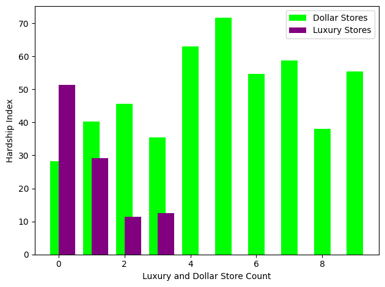

```python
x = ['0', '1','2','3','4','5','6','7','8','9']
X_axis = np.arange(len(x))

bar_width = 0.5#make the bars relatively small so we can fit everything
fig, ax = plt.subplots()#we're gonna be plotting two DFs on one plot
#read in both DFs, shifting the second one slightly so we can see everything without taking too much space
bars1 = ax.bar(avg_hardship_dollar['Dollar Store Count'], avg_hardship_dollar['HARDSHIP INDEX'], bar_width, color="lime", label='Dollar Stores')
bars2 = ax.bar(avg_hardship_lux['Luxury Store Count'], avg_hardship_lux['HARDSHIP INDEX'], bar_width, color="purple",label='Luxury Stores', align='edge')

ax.set_xlabel('Luxury and Dollar Store Count')#labels
ax.set_ylabel('Hardship Index')
#ax.set_title('Luxury and Dollar Store Count')#title
ax.legend()#legend
plt.tight_layout()#this makes them overlap less
plt.show()
```

This graph demonstrates how the count of luxury and dollar stores correlate with hardship index in the zipcodes they reside in (on average). This is perhaps the most easy to understand for those not familiar with the Chicago area. The decreasing trend in luxury stores and overall increasing trend up to the 5 dollar store mark is notable, though still somewhat confusing to us based on our initial assumptions that there would be a direct correlation with more dollar stores meaning higher poverty rates. Areas that are low-income and below the poverty level are more susceptible to food insecurity, and dollar stores are often a harbinger of food deserts. With more data, there would perhaps be a better correlation to see. We also would like to use the amount of grocery stores vs dollar stores to predict whether a zipcode is more likely to have higher rates of poverty, which is associated with food insecurity.

# Euclidean distance from Store vs Poverty Percent

Below was another EDA with the 2013 stores and census data (with zipcodes added) to see if there was a correlation between distance from stores and the poverty percentage metric. Like the above EDA, this was unfortunately not supportive of our hypothesis. However, we felt it was still worthwhile to include since this was our most complete grocery set and tested for distance, which is the basis of our research.

```
Slope:  -239.98802920441054
R^2:  0.028330718011431055
```

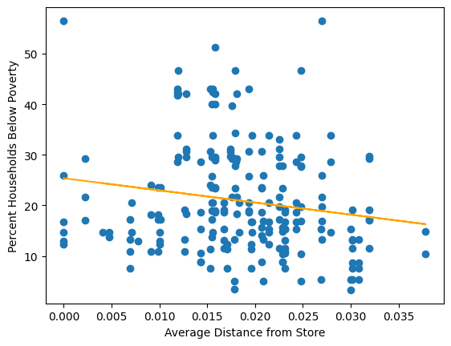

```python
from sklearn.metrics import pairwise_distances
import seaborn as sns

# extracting the longitude and latitude so we can compute euclidean distance
def extract_coordinates(location):
  lat, lon = map(float, location.strip("()").split(','))
  return lat, lon

# extract coordinates from the chicago grocery store dataset
chicago_2013[["latitude", "longitude"]] = chicago_2013["LOCATION"].apply(extract_coordinates).apply(pd.Series)

# isolating desired zipcodes
zipcodes = chicago_2013["ZIP CODE"].unique()
distance_matrices = {}
avg_distance_data = []

for zipcode in zipcodes:
  chicago_2013_zipcode = chicago_2013[chicago_2013["ZIP CODE"] == zipcode]
  chicago_2013_quant = chicago_2013_zipcode[["latitude", "longitude"]].values
  distance_matrix = pairwise_distances(chicago_2013_quant, metric = "euclidean")
  distance_df = pd.DataFrame(distance_matrix, index = chicago_2013_zipcode.index, columns = chicago_2013_zipcode.index)
  distance_matrices[zipcode] = distance_df

for zipcode, distance_df in distance_matrices.items():
  distances = distance_df.values
  non_zero_distances = distances[distances > 0]
  average_distance = non_zero_distances.mean() if len(non_zero_distances) > 0 else 0
  avg_distance_data.append({"Zipcode": zipcode, "avg_distance":average_distance})

avg_distance_df = pd.DataFrame(avg_distance_data)
avg_distance_df.sort_values(by="avg_distance", inplace=True)
avg_stores_per_cap = stores_per_cap.merge(avg_distance_df, on="Zipcode", how = "inner")
avg_stores_per_cap
x = avg_stores_per_cap["avg_distance"]
y = avg_stores_per_cap["PERCENT HOUSEHOLDS BELOW POVERTY"]
plt.scatter(x, y)

slope, intercept = np.polyfit(x, y, 1)
best_fit_line = slope * x + intercept
plt.plot(x, best_fit_line, color = "orange")
plt.xlabel('Average Distance from Store')#labels
plt.ylabel('Percent Households Below Poverty')
print("Slope: ", slope)

#r squared equation
ss_total = np.sum((y - np.mean(y))**2)  #total sum of squares
ss_residual = np.sum((y - best_fit_line)**2)  #residual sum of squares
r_squared = 1 - (ss_residual / ss_total)
print("R^2: ", r_squared)
plt.show()
```

# Choropleth Maps

Below are the maps of the Chicago area separated by zipcode. The first map plots hardship index, the second plots dollar stores, and the third luxury stores.

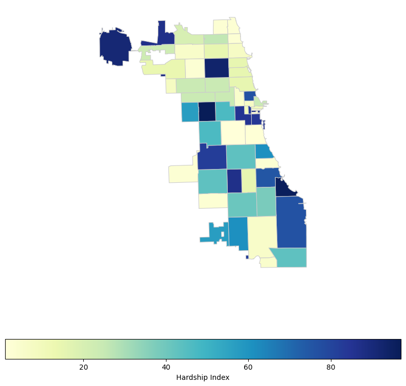

```python
#chloropleth vis
chic_map = gpd.read_file('/content/Kayla200212.github.io/Datasets/ChicagoMap/Zip_Codes.shp')
chic_map_df = chic_map.merge(stores_per_cap, how = 'left', left_index = True, right_index = True )

#define figs and axes
fig, ax = plt.subplots(1, figsize=(10, 10))

chic_map_df.plot(column='HARDSHIP INDEX', cmap='YlGnBu', linewidth=0.8, ax=ax, edgecolor = '0.8', legend=True, legend_kwds = {'label': "Hardship Index", 'orientation': "horizontal"})
ax.set_axis_off()#not necessary for us
plt.show()
```

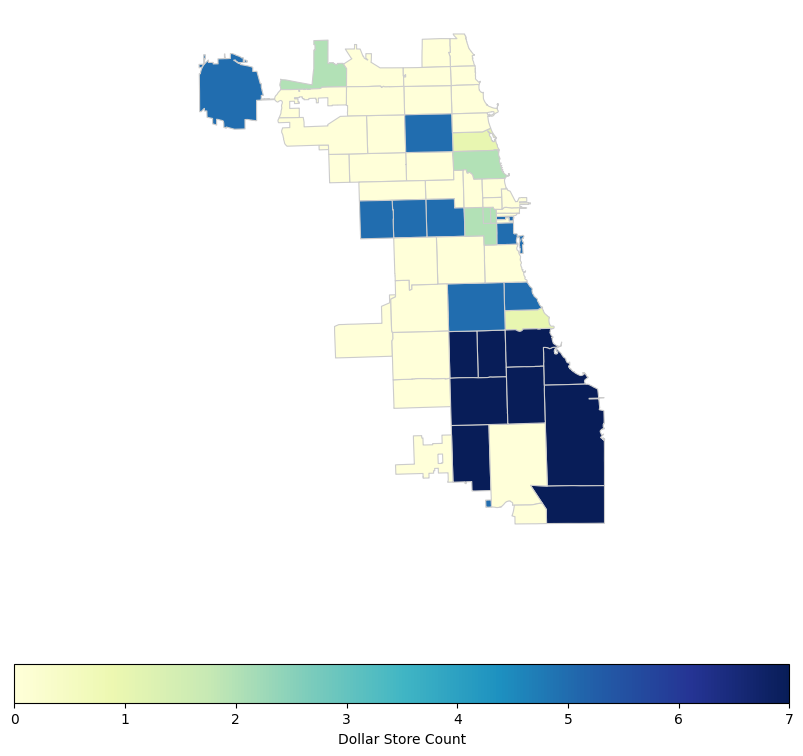

```python
chic_map_df= chic_map_df.fillna(0)#so that these zipcodes appear on the map

fig, ax = plt.subplots(1, figsize=(10, 10))
chic_map_df.plot(column='Dollar Store Count', cmap='YlGnBu', linewidth=0.8, ax=ax, edgecolor = '0.8', legend=True, legend_kwds = {'label': "Dollar Store Count", 'orientation': "horizontal"})
ax.set_axis_off()
plt.show()
```

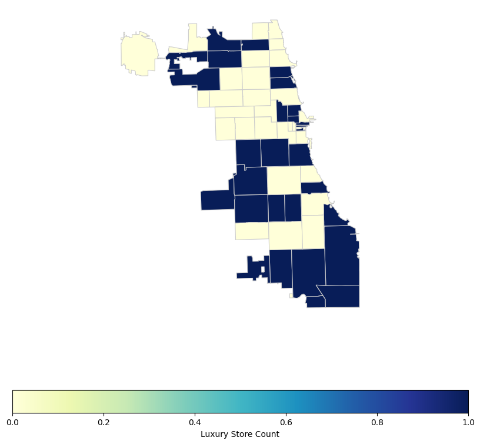

```python
fig, ax = plt.subplots(1, figsize=(10, 10))
chic_map_df.plot(column='Luxury Store Count', cmap='YlGnBu', linewidth=0.8, ax=ax, edgecolor = '0.8', legend=True, legend_kwds = {'label': "Luxury Store Count", 'orientation': "horizontal"})
ax.set_axis_off()
plt.show()
```

# Model

The kNN model below will use the poverty census ratings as well as luxury or dollar stores to predict overall hardship.

```python
features = ["PERCENT HOUSEHOLDS BELOW POVERTY", "PERCENT AGED 16+ UNEMPLOYED",
            "PERCENT AGED 25+ WITHOUT HIGH SCHOOL DIPLOMA", "PERCENT AGED UNDER 18 OR OVER 64",
            "PER CAPITA INCOME ", "Dollar Store Count"]
X_train_dict = stores_per_cap[features].to_dict(orient="records")
y_train = stores_per_cap["HARDSHIP INDEX"]

from sklearn.feature_extraction import DictVectorizer
from sklearn.preprocessing import StandardScaler
vec = DictVectorizer(sparse=False)
vec.fit(X_train_dict)
X_train = vec.transform(X_train_dict)

scaler = StandardScaler()
scaler.fit(X_train)
X_train_sc = scaler.transform(X_train)

from sklearn.neighbors import KNeighborsRegressor

# Fit a 10-nearest neighbors model.
model = KNeighborsRegressor(n_neighbors=10)
model.fit(X_train_sc, y_train)

# Calculate the model predictions on the training data.
y_train_pred = model.predict(X_train_sc)
y_train_pred

mse = ((y_train - y_train_pred) ** 2).mean()
mse
```

```
17.59594017094017
```

```python
features = ["PERCENT HOUSEHOLDS BELOW POVERTY", "PERCENT AGED 16+ UNEMPLOYED",
            "PERCENT AGED 25+ WITHOUT HIGH SCHOOL DIPLOMA", "PERCENT AGED UNDER 18 OR OVER 64",
            "PER CAPITA INCOME ", "Luxury Store Count"]
X_train_dict = stores_per_cap[features].to_dict(orient="records")
y_train = stores_per_cap["HARDSHIP INDEX"]

from sklearn.feature_extraction import DictVectorizer
from sklearn.preprocessing import StandardScaler
vec = DictVectorizer(sparse=False)
vec.fit(X_train_dict)
X_train = vec.transform(X_train_dict)

scaler = StandardScaler()
scaler.fit(X_train)
X_train_sc = scaler.transform(X_train)

from sklearn.neighbors import KNeighborsRegressor

# Fit a 10-nearest neighbors model.
model = KNeighborsRegressor(n_neighbors=10)
model.fit(X_train_sc, y_train)

# Calculate the model predictions on the training data.
y_train_pred = model.predict(X_train_sc)
y_train_pred

mse = ((y_train - y_train_pred) ** 2).mean()
print(mse)
stores_per_cap["Predicted Hardship Index (Luxury)"] = y_train_pred
```

```
13.169615384615382
```

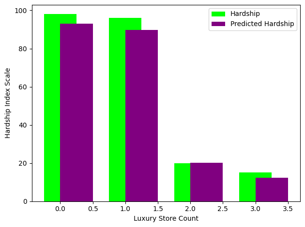

```python
x = ['0', '1','2','3']
X_axis = np.arange(len(x))

bar_width = 0.5#make the bars relatively small so we can fit everything
fig, ax = plt.subplots()#we're gonna be plotting two DFs on one plot
#read in both DFs, shifting the second one slightly so we can see everything without taking too much space
bars1 = ax.bar(stores_per_cap['Luxury Store Count'], stores_per_cap['HARDSHIP INDEX'], bar_width, color="lime", label='Hardship')
bars2 = ax.bar(stores_per_cap['Luxury Store Count'], stores_per_cap['Predicted Hardship Index (Luxury)'], bar_width, color="purple",label='Predicted Hardship', align='edge')

ax.set_xlabel('Luxury Store Count')#labels
ax.set_ylabel('Hardship Index Scale')
#ax.set_title('Luxury and Dollar Store Count')#title
ax.legend()#legend
plt.tight_layout()#this makes them overlap less
plt.show()
```

```python
features = ["PERCENT HOUSEHOLDS BELOW POVERTY", "PERCENT AGED 16+ UNEMPLOYED",
            "PERCENT AGED 25+ WITHOUT HIGH SCHOOL DIPLOMA", "PERCENT AGED UNDER 18 OR OVER 64",
            "PER CAPITA INCOME ", "Dollar Store Count"]
X_train_dict = stores_per_cap[features].to_dict(orient="records")
y_train = stores_per_cap["HARDSHIP INDEX"]

from sklearn.feature_extraction import DictVectorizer
from sklearn.preprocessing import StandardScaler
vec = DictVectorizer(sparse=False)
vec.fit(X_train_dict)
X_train = vec.transform(X_train_dict)

scaler = StandardScaler()
scaler.fit(X_train)
X_train_sc = scaler.transform(X_train)

from sklearn.neighbors import KNeighborsRegressor

# Fit a 10-nearest neighbors model.
model = KNeighborsRegressor(n_neighbors=10)
model.fit(X_train_sc, y_train)

# Calculate the model predictions on the training data.
y_train_pred = model.predict(X_train_sc)
y_train_pred

mse = ((y_train - y_train_pred) ** 2).mean()
print(mse)
stores_per_cap["Predicted Hardship Index (Dollar)"] = y_train_pred
stores_per_cap.sort_values(by="Dollar Store Count")
```

```
17.59594017094017
```

|  | Zipcode | PERCENT OF HOUSING CROWDED | PERCENT HOUSEHOLDS BELOW POVERTY | PERCENT AGED 16+ UNEMPLOYED | PERCENT AGED 25+ WITHOUT HIGH SCHOOL DIPLOMA | PERCENT AGED UNDER 18 OR OVER 64 | PER CAPITA INCOME | HARDSHIP INDEX | Luxury Store Count | Dollar Store Count | Predicted Hardship Index (Luxury) | Predicted Hardship Index (Dollar) |
| --- | --- | --- | --- | --- | --- | --- | --- | --- | --- | --- | --- | --- |
| 0 | 60007 | 3.6 | 15.4 | 7.1 | 10.9 | 30.3 | 25828 | 24.0 | 0.0 | 0.0 | 23.9 | 23.8 |
| 180 | 60646 | 2.7 | 8.6 | 12.4 | 13.4 | 35.5 | 27751 | 25.0 | 1.0 | 0.0 | 30.7 | 28.5 |
| 179 | 60646 | 2.0 | 5.4 | 9.0 | 11.5 | 39.5 | 32875 | 21.0 | 1.0 | 0.0 | 26.1 | 19.1 |
| 126 | 60631 | 3.6 | 15.4 | 7.1 | 10.9 | 30.3 | 25828 | 24.0 | 0.0 | 0.0 | 23.9 | 23.8 |
| 125 | 60631 | 2.0 | 5.4 | 9.0 | 11.5 | 39.5 | 32875 | 21.0 | 0.0 | 0.0 | 21.8 | 19.1 |
| ... | ... | ... | ... | ... | ... | ... | ... | ... | ... | ... | ... | ... |
| 82 | 60620 | 4.0 | 10.4 | 11.7 | 17.7 | 36.9 | 23482 | 37.0 | 0.0 | 9.0 | 33.2 | 38.3 |
| 81 | 60620 | 3.6 | 29.6 | 23.0 | 16.5 | 41.0 | 17285 | 66.0 | 0.0 | 9.0 | 61.9 | 62.8 |
| 80 | 60620 | 3.8 | 46.6 | 28.0 | 28.5 | 42.5 | 11888 | 94.0 | 0.0 | 9.0 | 90.9 | 80.8 |
| 85 | 60620 | 1.1 | 16.9 | 20.8 | 13.7 | 42.6 | 19713 | 48.0 | 0.0 | 9.0 | 48.4 | 47.2 |
| 84 | 60620 | 0.9 | 5.1 | 8.0 | 3.7 | 40.5 | 39523 | 12.0 | 0.0 | 9.0 | 13.2 | 26.8 |

234 rows × 12 columns

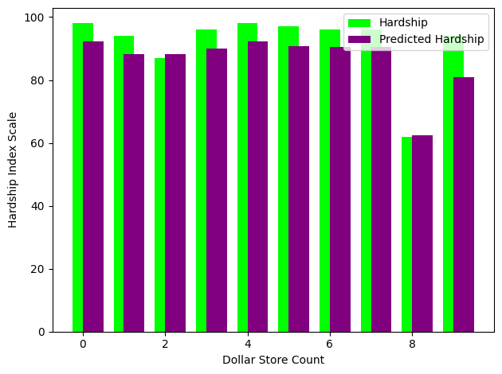

```python
x = ['0', '1','2','3','4','5','6','7','8','9']
X_axis = np.arange(len(x))

bar_width = 0.5#make the bars relatively small so we can fit everything
fig, ax = plt.subplots()#we're gonna be plotting two DFs on one plot
#read in both DFs, shifting the second one slightly so we can see everything without taking too much space
bars1 = ax.bar(stores_per_cap['Dollar Store Count'], stores_per_cap['HARDSHIP INDEX'], bar_width, color="lime", label='Hardship')
bars2 = ax.bar(stores_per_cap['Dollar Store Count'], stores_per_cap['Predicted Hardship Index (Dollar)'], bar_width, color="purple",label='Predicted Hardship', align='edge')

ax.set_xlabel('Dollar Store Count')#labels
ax.set_ylabel('Hardship Index Scale')
#ax.set_title('Luxury and Dollar Store Count')#title
ax.legend()#legend
plt.tight_layout()#this makes them overlap less
plt.show()
```

Based on these kNN models, the trends are followed for hardship index in both luxury and dollar stores, but the proximity would indicate a degree of overfitting. The MSE for the dollar store prediction was about 18%, while for luxury stores the MSE was around 13%, which is small, but in line with predictions for dollar stores having higher hardship index.